# Diamond sizes

2018-07-15

## Size and Cut, Color, and Clarity

Diamonds with lower quality cuts (cuts are ranked from “Ideal” to “Fair”) tend to be be larger.

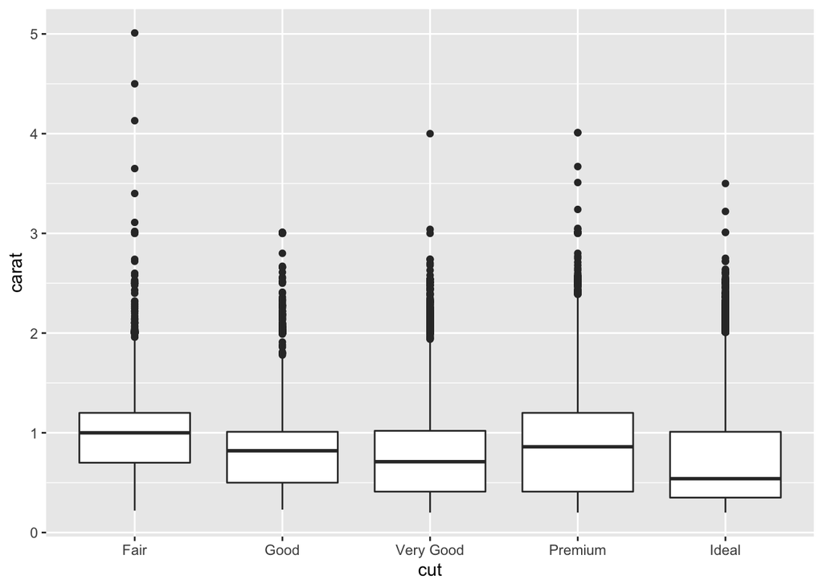

Likewise, diamonds with worse color (diamond colors are ranked from J (worst) to D (best)) tend to be larger:

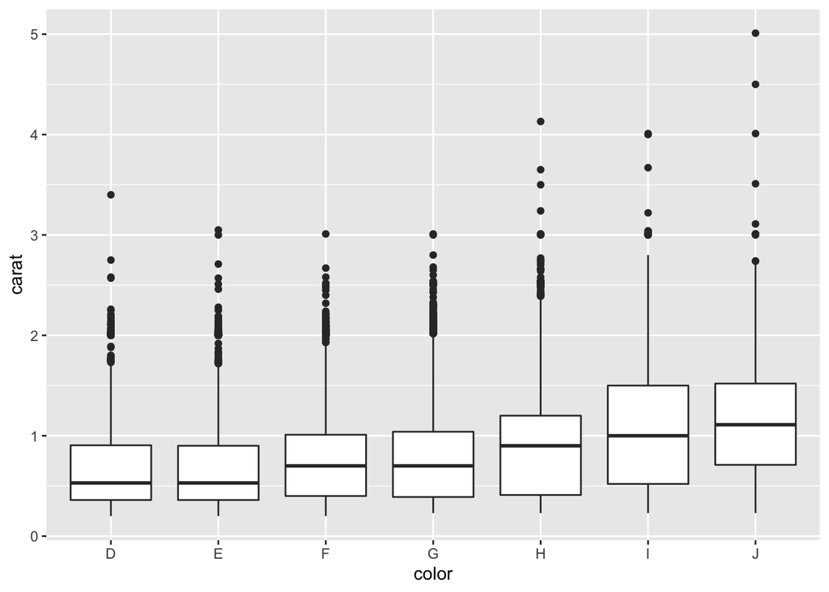

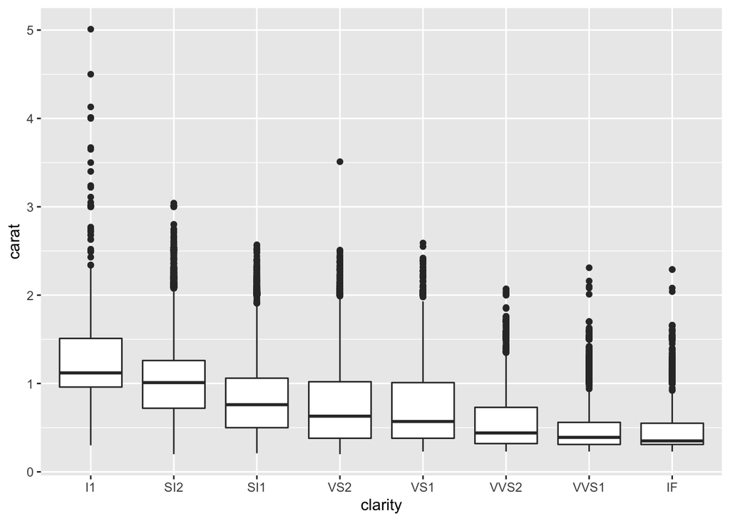

These patterns are consistent with there being a profitability threshold for retail diamonds that is a function of carat, clarity, color, cut and other characteristics. A diamond may be profitable to sell if a poor value of one feature, for example, poor clarity, color, or cut, is be offset by a good value of another feature, such as a large size. This can be considered an example of [Berkson’s paradox](https://en.wikipedia.org/wiki/Berkson%27s_paradox).

## Largest Diamonds

We have data about 53,940 diamonds. Only 126 (0.2%) are larger than 2.5 carats. The distribution of the remainder is shown below:

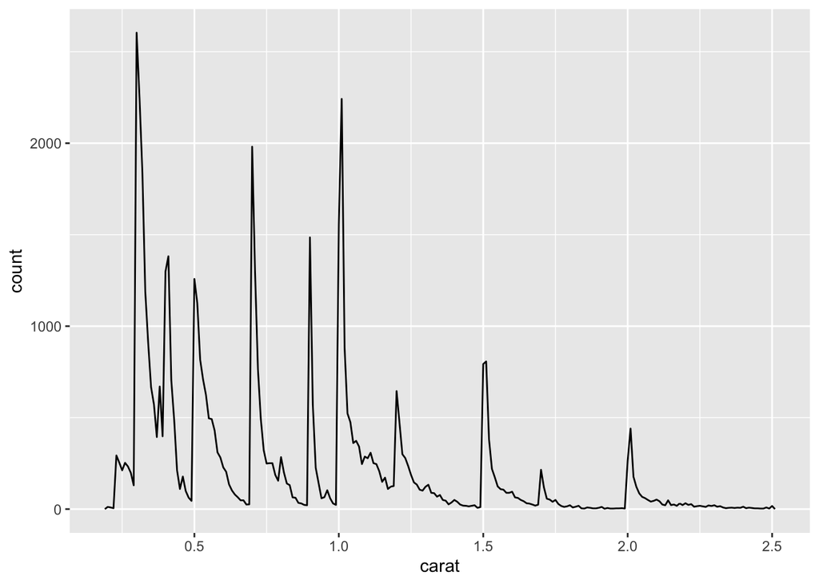

The frequency distribution of diamond sizes is marked by spikes at whole-number and half-carat values, as well as several other carat values corresponding to fractions.

The largest twenty diamonds (by carat) in the datasets are,

The largest 20 diamonds in the `diamonds` dataset.

| carat | cut | color | clarity |
| --- | --- | --- | --- |
| 5.01 | Fair | J | I1 |
| 4.50 | Fair | J | I1 |
| 4.13 | Fair | H | I1 |
| 4.01 | Premium | I | I1 |
| 4.01 | Premium | J | I1 |
| 4.00 | Very Good | I | I1 |
| 3.67 | Premium | I | I1 |
| 3.65 | Fair | H | I1 |
| 3.51 | Premium | J | VS2 |
| 3.50 | Ideal | H | I1 |
| 3.40 | Fair | D | I1 |
| 3.24 | Premium | H | I1 |
| 3.22 | Ideal | I | I1 |
| 3.11 | Fair | J | I1 |
| 3.05 | Premium | E | I1 |
| 3.04 | Very Good | I | SI2 |
| 3.04 | Premium | I | SI2 |
| 3.02 | Fair | I | I1 |
| 3.01 | Premium | I | I1 |
| 3.01 | Premium | F | I1 |